# Nationality-Based Discrimination in Mexico’s Refugee Determination Process

Juan C. Venancio

## Introduction

The 1951 United Nations Refugees Convention establishes the fundamental framework of international asylum law for member states of the United Nations. Since 1951, member states have met in other conventions to re-contextualize and re-interpret this legal framework in new correspondence to their national interests and needs (OAU Convention 1969 & 1984 Cartagena Declaration), but the legal principles establishing the definition of a refugee remain identical since its conception. According to the 1951 Convention, a refugee is any person that based on a well-founded fear of persecution on the basis of their race, religion, nationality, membership to a particular social group, or political opinion, merits the international protection of a sovereign entity outside of their country of origin. As it stands, in 2022, approximately 108.4 million people were forcibly displaced, and of those forcibly displaced, 35.3 million were categorized as refugees. According to the UNHCR, 76% of the world’s refugees are hosted in low and middle-income countries across the world.

Since its inception, Mexico has not historically been a destination country for migrants and refugees. At most, the country became a transit country for Central and South American migrants that headed to the United States during periods of increased generalized drug violence, civil wars, and economic destitution between the late 1980s and early 2000s. Over the last decade alone, the number of refugee applications submitted to and processed by the Mexican government has exponentially increased, and this data is indicative of Mexico’s evolving role as a destination country for many immigrants. However, given the exponential increase in applications and Mexico’s limited institutional capacity as a middle-income country, questions have emerged whether COMAR, Mexico’s refugee processing institution, selective prioritizes applications of certain nationalities and therefore discriminates against others. I would like to explore this phenomenon, and compile/analyze data that uncover potential discriminatory institutional practices on the basis of Hispanic and non-Hispanic categorizations, as well as suggest potential policy recommendations. I am planning to use data from the Mexican Commission for Refugee Assistance.

## Project Abstract & Methodology (Data Section)

Research Question: To What Extent Does Hispanic Nationality Impact Refugee Status Determination in Mexico?

Hypothesis: I hypothesize, that migrants who indicate a Hispanic nationality tend to have higher possibilities to successfully obtain refugee status in Mexico. As a result, I expect that migrants from Haiti, the non-Spanish Caribbean, and other parts of the world tend to have lower possibilities at refugee resettlement. Additionally, though the Mexican Government has made advances to expand their refugee granting criteria, because the 1951 UN Convention of Refugees provides a large number of successful reugee claims to migrants with “well-founded fear of persecution”, then I also predict that Mexican institutions accept Spanish-speaking Latin-Americans at a significant larger rate. For this project, I will analyze the Mexican Government’s Commission on Refugee Assistance open data set that I will use to assess the several reasons that migrants tend to leave their countries of origin. If Venezuelans, Hondurans, and other spanish speaking Latin Americans have a higher rate of refugee success, then that will make my hypothesis correct. If other types of nationalities have a higher rate of success, then I will be proven wrong. In any case, I am also interested in observing the variability of application success and the type of application submitted.

Methodology: My unit of measurement is whether an immigrant was granted refugee status or not. If the immigrant was provided with a refugee status, implying that the migrant was considered to have had a well-founded fear of persecution, then I will indicate that with 1 for successful application. If a migrant was rejected, then I will indicate that with 0. The independent variable will be the migrant’s nationality. The explanatory variable of interest is whether the nationality impacts the likelihood that a migrant gets refugee status in Mexico.

To test this hypothesis, I used the Mexican Government’s Commission on Refugee Assistance (COMAR) open data set on refugee applications to conduct a statistical data analysis and produce a linear regression model assessing refugee status determination in Mexico between 2013 and 2023. I downloaded the dataset and coded my visualizations, results, and subsequent models using R.

```r
#set up all libraries needed for this project
library(tidyverse, ggplot2)
library(knitr)

#import data needed
submitted_applications <- read.csv("//Users//jvenancio//Downloads//COMAR_Thesis_Data_Solicitudes.csv")
application_results <- read.csv("//Users//jvenancio//Downloads//COMAR_Thesis_Data_Resoluciones.csv")
```

```r
#count how many applications were submitted per nationality + create data table
apps_sub_per_nationality <- submitted_applications |>
  count(NACIONALIDAD) |>
  rename(applications = n, Nationality = NACIONALIDAD)
```

```r
#count how many applications were submitted per year + create data table
apps_sub_per_year <- submitted_applications |>
  count(AÑO) |>
  rename(applications = n, year = AÑO)

# 'submitted_applications' is my data frame
```

```r
#count how many applications were processed per year + create data table
apps_proc_per_year <- application_results |>
  count(AÑO_RESOLUCION) |>
  rename(applications = n, year = AÑO_RESOLUCION)



#count the end result of the applications that were processed in total from 2013-23
apps_proc_result <- application_results |>
  count(SENTIDO_RESOLUCIÓN)

# Print the data table
kable(apps_proc_per_year, caption = "Applications Processed per Year")
```

Applications Processed per Year

| year | applications |
| --- | --- |
| 2013 | 781 |
| 2014 | 1273 |
| 2015 | 2007 |
| 2016 | 4256 |
| 2017 | 6513 |
| 2018 | 11900 |
| 2019 | 24324 |
| 2020 | 17939 |
| 2021 | 37235 |
| 2022 | 40983 |
| 2023 | 24842 |

```r
#count the end result of the applications that were processed (positive) in total from 2013-23 per nationality
apps_proc_result_pos <- application_results |>
  filter(SENTIDO_RESOLUCIÓN == "Resolución Positiva")

table_result <- table(apps_proc_result_pos$NACIONALIDAD)

# Print the kable table
kable(as.data.frame(table_result), caption = "Positive Resolutions per Nationality")
```

Positive Resolutions per Nationality

| Var1 | Freq |
| --- | --- |
| Afganistán | 6 |
| Angola | 6 |
| Argelia | 1 |
| Argentina | 6 |
| Bangladesh | 7 |
| Belice | 4 |
| Benín | 6 |
| Brasil | 4 |
| Burkina Faso | 14 |
| Camerún | 44 |
| Chad | 1 |
| Chile | 6 |
| China | 1 |
| Colombia | 257 |
| Congo | 16 |
| Costa de Marfil | 2 |
| Costa Rica | 5 |
| Cuba | 4001 |
| Ecuador | 59 |
| Egipto | 4 |
| El Salvador | 8470 |
| EL SALVADOR | 19 |
| Eritrea | 1 |
| España | 3 |
| Estados Unidos de América | 1 |
| Etiopia | 2 |
| Federación de Rusia | 48 |
| Georgia | 1 |
| Ghana | 38 |
| Granada | 1 |
| Guatemala | 2211 |
| GUATEMALA | 10 |
| Guinea | 38 |
| Guinea Ecuatorial | 1 |
| Guinea-Bissau | 1 |
| Haití | 2190 |
| Honduras | 27115 |
| Hong Kong | 1 |
| Hungría | 1 |
| India | 4 |
| Irak | 12 |
| Irán | 10 |
| Israel | 2 |
| Jamaica | 7 |
| Kirguistán | 1 |
| Mali | 2 |
| Marruecos | 5 |
| Mauritania | 6 |
| Nepal | 1 |
| Nicaragua | 1291 |
| NICARAGUA | 3 |
| Nígeria | 34 |
| Países Bajos | 1 |
| Pakistán | 8 |
| Palestina | 5 |
| Panamá | 3 |
| Perú | 14 |
| República de Kazajstán | 1 |
| Republica de Turquia | 5 |
| República Democrática del Congo | 13 |
| República Dominicana | 25 |
| República Islámica de Irán | 1 |
| Rusia | 4 |
| Rwanda | 1 |
| Senegal | 3 |
| Sierra Leona | 9 |
| Siria | 32 |
| Somalia | 2 |
| Sri Lanka | 3 |
| Tanzania | 1 |
| Tayikistán | 1 |
| Togo | 18 |
| Ucrania | 49 |
| Uganda | 2 |
| Uruguay | 4 |
| Uzbekistán | 1 |
| Venezuela | 16366 |
| VENEZUELA | 198 |
| Yemen | 29 |

```r
apps_proc_result_neg <- application_results |>
  filter(SENTIDO_RESOLUCIÓN == "Resolución Negativa")

#create nice table of negative resolutions


table_result2 <- table(apps_proc_result_neg$NACIONALIDAD)

# Print the kable table
kable(as.data.frame(table_result2), caption = "Negative Resolutions per Nationality")
```

Negative Resolutions per Nationality

| Var1 | Freq |
| --- | --- |
| Afganistán | 1 |
| Albania | 4 |
| Alemania | 5 |
| Angola | 5 |
| Argentina | 120 |
| Austria | 1 |
| Bangladesh | 2 |
| Bélgica | 1 |
| Belice | 8 |
| Benín | 2 |
| Bolivia | 10 |
| Brasil | 27 |
| Burkina Faso | 15 |
| Camerún | 24 |
| Canadá | 2 |
| Chile | 22 |
| China, República Popular | 14 |
| Colombia | 1013 |
| Congo | 7 |
| Corea del Sur | 1 |
| Costa de Marfil | 9 |
| Costa Rica | 22 |
| Cuba | 4614 |
| CUBA | 7 |
| Dominica | 2 |
| Ecuador | 88 |
| El Salvador | 3431 |
| EL SALVADOR | 35 |
| España | 14 |
| Estados Unidos de América | 23 |

[output cut: 61 more lines]

These three tables demonstrate the total number of positive resolutoins, and the total number of negative resolutions for all refugee applicants in Mexico between 2013-2023. I proceed with more interpretations of the data.

These three tables are plotted summaries of my dependent variable.

## Results

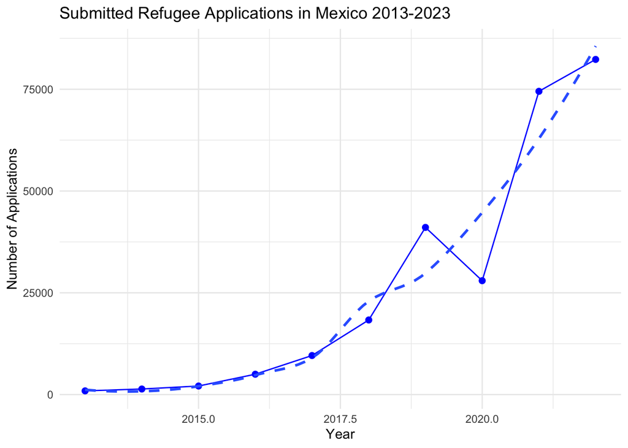

```r
library(ggplot2)

# data frames: apps_sub_per_year, apps_proc_per_year, apps_proc_result

# Creating the line graph for submitted applications per year
ggplot(data = apps_sub_per_year |> filter(year != 2023),
       aes(x = year, y = applications, group = 1)) +
  geom_line(color = "blue") +
  geom_point(color = "blue", size = 2) +
  geom_smooth(linetype = 2, se = FALSE) +
  labs(title = "Submitted Refugee Applications in Mexico 2013-2023",
       x = "Year",
       y = "Number of Applications") +
  theme_minimal()
```

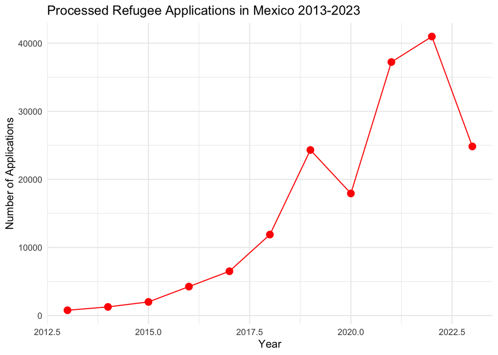

```r
# Creating the line graph for processed applications per year
ggplot(data = apps_proc_per_year, aes(x = year, y = applications, group = 1)) +
  geom_line(color = "red") +
  geom_point(color = "red", size = 3) +
  labs(title = "Processed Refugee Applications in Mexico 2013-2023",
       x = "Year",
       y = "Number of Applications") +
  theme_minimal()
```

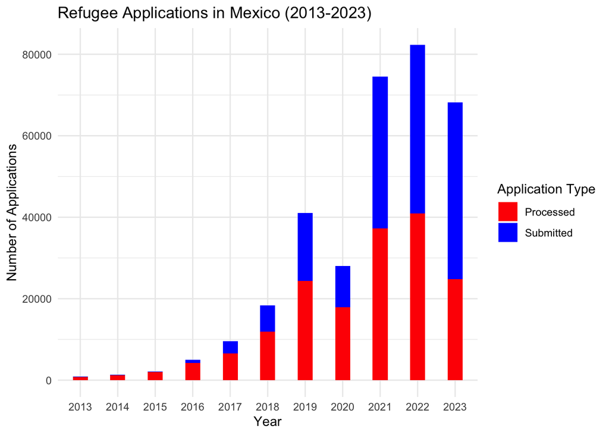

```r
library(ggplot2)


merged_data <- merge(apps_sub_per_year, apps_proc_per_year, by = "year", all = TRUE)


ggplot(data = merged_data, aes(x = as.factor(year))) +
  geom_bar(aes(y = applications.x, fill = "Submitted"), stat = "identity", position = "dodge", width = 0.4) +
  geom_bar(aes(y = applications.y, fill = "Processed"), stat = "identity", position = "dodge", width = 0.4) +
  labs(title = "Refugee Applications in Mexico (2013-2023)",
       x = "Year",
       y = "Number of Applications") +
  scale_fill_manual(name = "Application Type", values = c("Submitted" = "blue", "Processed" = "red")) +
  theme_minimal()
```

Description: Mexico as a Destination Country for Immigrants

```r
# 'application_results' is my data frame
library(dplyr)
library(knitr)

# Filter for positive resolutions
apps_proc_result_pos <- application_results |>
  filter(SENTIDO_RESOLUCIÓN == "Resolución Positiva")

# Count applications per nationality for positive resolutions
table_result <- table(apps_proc_result_pos$NACIONALIDAD)


# Count applications per positive resolution type
apps_proc_result_pos <- application_results |>
  filter(SENTIDO_RESOLUCIÓN == "Resolución Positiva") |>
  count(NACIONALIDAD)

# Count applications per negative resolution type
apps_proc_result_neg <- application_results |>
  filter(SENTIDO_RESOLUCIÓN == "Resolución Negativa") |>
  count(NACIONALIDAD)

# Merge the two tables
merged_table <- merge(apps_proc_result_pos, apps_proc_result_neg, by = "NACIONALIDAD", all = TRUE)

# Rename columns for clarity
colnames(merged_table) <- c("Nationality", "Positive_Resolutions", "Negative_Resolutions")


# List of countries to filter
selected_countries <- c("Honduras", "El Salvador", "Guatemala", "Haití", "Brasil", "Federación de Rusia", "Ghana", "India", "Nicaragua", "Venezuela", "Nígeria")

# Filter the merged table for the selected countries
filtered_merged_table <- merged_table |>
  filter(Nationality %in% selected_countries)


# Count applications per positive resolution type
apps_proc_result_pos <- application_results |>
  filter(SENTIDO_RESOLUCIÓN == "Resolución Positiva") |>
  count(NACIONALIDAD)

# Count applications per negative resolution type
apps_proc_result_neg <- application_results |>
  filter(SENTIDO_RESOLUCIÓN == "Resolución Negativa") |>
  count(NACIONALIDAD)

# Merge the two tables
merged_table <- merge(apps_proc_result_pos, apps_proc_result_neg, by = "NACIONALIDAD", all = TRUE)

# Rename columns for clarity
colnames(merged_table) <- c("Nationality", "Positive_Resolutions", "Negative_Resolutions")

# Add a percentage column
merged_table$Percentage_Positive <- paste0(round((merged_table$Positive_Resolutions /
                                                   (merged_table$Positive_Resolutions + merged_table$Negative_Resolutions)) * 100, 1), "%")

# Filter out the total row
filtered_merged_table <- merged_table |>
  filter(!is.na(Nationality))

# List of countries to filter
selected_countries <- c("Honduras", "El Salvador", "Guatemala", "Haití", "Brasil", "Federación de Rusia", "Ghana", "India", "Nicaragua", "Venezuela", "Nígeria")

# Filter the merged table for the selected countries
filtered_merged_table <- filtered_merged_table |>
  filter(Nationality %in% selected_countries)


# Count applications per positive resolution type
apps_proc_result_pos <- application_results |>
  filter(SENTIDO_RESOLUCIÓN == "Resolución Positiva") |>
  count(NACIONALIDAD)

# Count applications per negative resolution type
apps_proc_result_neg <- application_results |>
  filter(SENTIDO_RESOLUCIÓN == "Resolución Negativa") |>
  count(NACIONALIDAD)

# Merge the two tables
merged_table <- merge(apps_proc_result_pos, apps_proc_result_neg, by = "NACIONALIDAD", all = TRUE)

# Rename columns for clarity
colnames(merged_table) <- c("Nationality", "Positive_Resolutions", "Negative_Resolutions")

# Add a percentage column (rounded to the nearest whole number)
merged_table$Percentage_Positive <- paste0(round((merged_table$Positive_Resolutions /
                                                   (merged_table$Positive_Resolutions + merged_table$Negative_Resolutions)) * 100), "%")

# Filter out the total row
filtered_merged_table <- merged_table |>
  filter(!is.na(Nationality))

# List of countries to filter
selected_countries <- c("Honduras", "El Salvador", "Guatemala", "Haití", "Brasil", "Federación de Rusia", "Ghana", "India", "Nicaragua", "Venezuela", "Nígeria")

# Filter the merged table for the selected countries
filtered_merged_table <- filtered_merged_table |>
  filter(Nationality %in% selected_countries)
filtered_merged_table <- arrange(filtered_merged_table, desc(Percentage_Positive))


# Create a nice-looking table
kable(
  filtered_merged_table,
  format = "html",
  col.names = c("Nationality", "Positive Resolutions", "Negative Resolutions", "Percentage of Positive Resolutions"),
  caption = "Refugee Application Outcomes for Top Hispanic and Non-Hispanic Nationalities (2013-2023)",
   align = "c", # optional, adjust alignment as needed
  width = "100%", # set the table width
  table.attr = 'style="width:100%;"' # set the width attribute in the HTML table tag
)
```

Refugee Application Outcomes for Top Hispanic and Non-Hispanic Nationalities (2013-2023)

| Nationality | Positive Resolutions | Negative Resolutions | Percentage of Positive Resolutions |
| --- | --- | --- | --- |
| Venezuela | 16366 | 880 | 95% |
| Honduras | 27115 | 8111 | 77% |
| El Salvador | 8470 | 3431 | 71% |
| Federación de Rusia | 48 | 42 | 53% |
| Guatemala | 2211 | 2242 | 50% |
| Nicaragua | 1291 | 1324 | 49% |
| Nígeria | 34 | 41 | 45% |
| Ghana | 38 | 64 | 37% |
| Haití | 2190 | 10486 | 17% |
| Brasil | 4 | 27 | 13% |
| India | 4 | 33 | 11% |

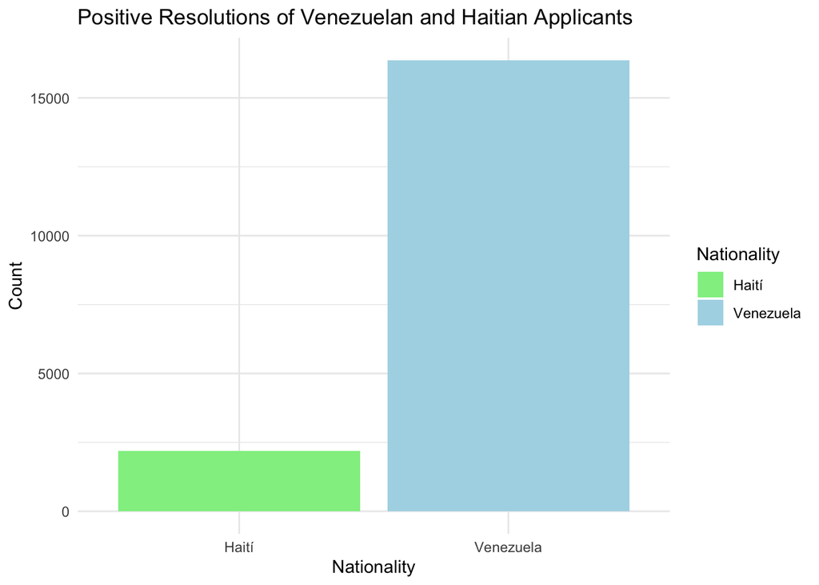

```r
# 'filtered_merged_table' is my data frame
library(dplyr)
library(ggplot2)

# Filter the data for Venezuela and Haiti
venezuela_data <- filtered_merged_table |>
  filter(Nationality == "Venezuela")

haiti_data <- filtered_merged_table |>
  filter(Nationality == "Haití")

# Check if the filtered data frames are not empty
if (nrow(venezuela_data) > 0 && nrow(haiti_data) > 0) {
  # Combine the data for Venezuela and Haiti
  bar_data <- rbind(venezuela_data, haiti_data)

  # Create a side-by-side bar plot
  ggplot(bar_data, aes(x = Nationality, y = Positive_Resolutions, fill = Nationality)) +
    geom_bar(stat = "identity", position = "dodge") +
    labs(title = "Positive Resolutions of Venezuelan and Haitian Applicants",
         x = "Nationality",
         y = "Count") +
    scale_fill_manual(values = c("Venezuela" = "lightblue", "Haití" = "lightgreen")) +
    theme_minimal()
} else {
  cat("No data found for Venezuela or Haiti.\n")
}
```

## Paragraph Summary:

These two data pieces are also essential to answer my research question. As a reminder, I am investigating whether the nationality of an applicant impacts the likelihood that they receive refugee status in Mexico. My hypothesis was that if an applicant is from a Spanish-speaking country, then they are more likely to acquire refugee status. If an applicant is from a non-Spanish-speaking country, then they are more likely to get rejected.

Based on these data visuals, this deep-dive case analysis further corroborates my initial findings. First, the nationality that is the most negatively impacted is Haiti. According to my data set, while 2190 Haitians managed to acquire refugee status in Mexico, 10486 Haitian applicants have been rejected over the last decade. Haiti is a country in the Caribbean, whose official language is Haitian Creole.

The reason why I specifically analyzed both cases is because arguably both countries are experiencing the similar political contexts in contemporary Latin-American history, and are often impacted by economic and environmental destitution in the same way. I would have expected that if nationality and the corresponding racial implications were not contributing determinants to refugee acquisition, then applicants from these two countries would have been admitted at statistically similar rates. However, despite their similar political and economic contexts, there is a drastically different outcome in refugee status determination in Mexico. As a result, the incredibly large disparity among admissions rate is telling of a correlation that benefits applicants of Hispanic origin at large.

```r
library(dplyr)
library(modelsummary)
library(broom)



spanish_speaking_countries <- c("Argentina","Chile","Colombia","Costa Rica","Cuba","Ecuador","El Salvador","EL SALVADOR","España","Guatemala","GUATEMALA","Guinea Ecuatorial","Honduras","Nicaragua","NICARAGUA","Panamá","Perú","República Dominicana","Uruguay","Venezuela","VENEZUELA")

data <- application_results |>
  mutate(spanish_speaking = if_else(NACIONALIDAD %in% spanish_speaking_countries, 1, 0),
         approved = if_else(SENTIDO_RESOLUCIÓN == "Resolución Positiva", 1, 0))

fit1 <- lm(approved ~ spanish_speaking + SEXO + EDAD, data = data)


modelsummary(fit1)
```

|  | (1) |
| --- | --- |
| (Intercept) | 0.116 |
|  | (0.005) |
| spanish_speaking | 0.313 |
|  | (0.003) |
| SEXOM | -0.126 |
|  | (0.002) |
| EDAD | 0.002 |
|  | (0.000) |
| Num.Obs. | 172053 |
| R2 | 0.082 |
| R2 Adj. | 0.082 |
| AIC | 221957.1 |
| BIC | 222007.4 |
| Log.Lik. | -110973.543 |
| RMSE | 0.46 |

```r
tidy_results <- tidy(fit1)
kable(tidy_results, caption = "Linear Regression Coefficients", digits = 3)
```

Linear Regression Coefficients

| term | estimate | std.error | statistic | p.value |
| --- | --- | --- | --- | --- |
| (Intercept) | 0.116 | 0.005 | 23.511 | 0 |
| spanish_speaking | 0.313 | 0.003 | 104.947 | 0 |
| SEXOM | -0.126 | 0.002 | -53.112 | 0 |
| EDAD | 0.002 | 0.000 | 20.340 | 0 |

In this research study, I ran a linear regression analysis assessing the impact that hispanic nationality has on refugee status determination in Mexico. For this linear regression, I assessed the relationship between the independent variable on the application outcome for all 172,053 processed applications. The linear analysis additionally evaluates the result of the regression in 0.001, 0.01, 0.05, 0.1, and 1 test values.

Null Hypothesis (H0): There is no significant impact of Hispanic nationality on the likelihood of a migrant being granted refugee status in Mexico.

Alternative Hypothesis (H1): Hispanic Nationality Significantly influences the likelihood of a migrant being granted refugee status in Mexico.

The results of my study indicated a p-value of <2.2e-16. In written form this p-value is 2.2 times 10 to the power of -16, indicating an exceedingly small value that passes is less than all alpha values indicated in my regression.

As a result of this incredibly small p-value, I am able to reject the null hypothesis with all given test values, and my linear regression model indicates that there is statistically significant data to indicate that Hispanic Nationality influences Refugee Status Determination in Mexico. In the context of my research question, the coefficient for the spanish-speaking variable was .313 percentage points, indicating that there is statistically significant data that indicates that an applicant of Hispanic nationality has a 31% higher probability to gain refugee admissions in Mexico, over applicants that indicated a non-Hispanic nationality. Interpreted further, non-Hispanic nationalities only have about a 11-12% chance of gaining refugee status admissions, as demonstrated by the y-intercept of the regression. Similarly, the control variables were an applicants sex and age. In comparison to the spanish-speaking variables, though their p-values were also small, the impact magintude of both variables was not as strong as the spanish-speaking variable.

Ultimately, the linear regression demonstrates a strong positive correlation between Hispanic nationality and refugee status admissions. However, because of possible confounding and external variables, I am not able to prove causality given the information. For example, in the context of migration, there various external factors that lead to different refugee status outcomes. Possible confounding variables include, but are not limited to, motive for migration, socioeconomic status of a migrant, legal aid at their disposal, and institutional capacity. However, I am confident that my data produced a very meaningful relationship.

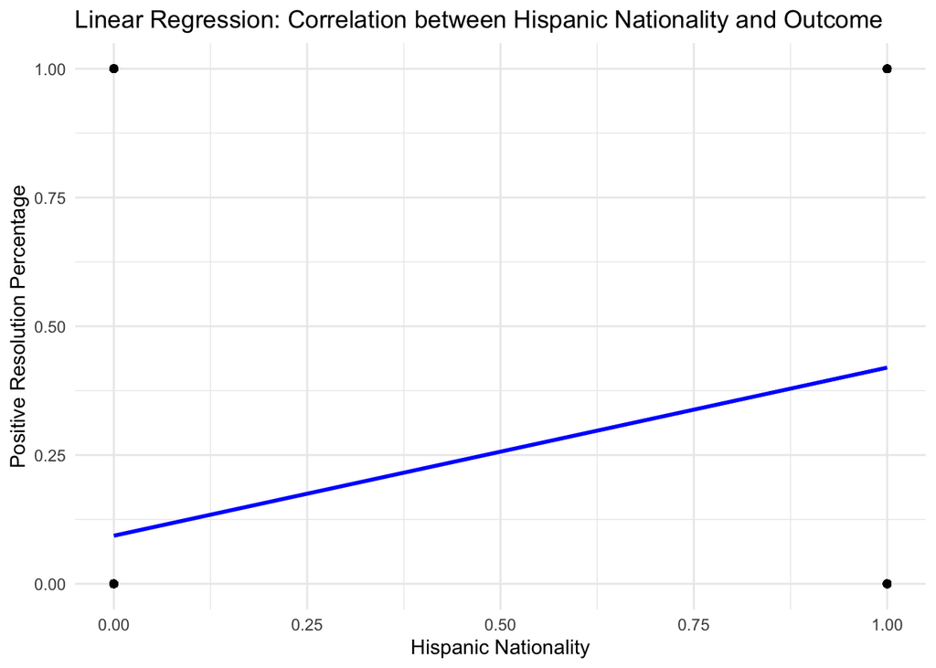

```r
# Install and load necessary packages if not already installed
if (!requireNamespace("ggplot2", quietly = TRUE)) {
  install.packages("ggplot2")
}
if (!requireNamespace("dplyr", quietly = TRUE)) {
  install.packages("dplyr")
}

# Load libraries
library(ggplot2)
library(dplyr)

# Your linear regression model
model <- lm(formula = approved ~ spanish_speaking, data = data)

# Create a dataframe for predictions
predictions <- data.frame(data, predicted = predict(model))

# Plotting the data and the regression line
ggplot(predictions, aes(x = spanish_speaking, y = approved)) +
  geom_point() +  # Scatter plot of the data points
  geom_line(aes(x = spanish_speaking, y = predicted), color = "blue", size = 1) +  # Regression line
  labs(title = "Linear Regression: Correlation between Hispanic Nationality and Outcome",
       x = "Hispanic Nationality",
       y = "Positive Resolution Percentage") +
  theme_minimal()
```

## Conclusion

For the purposes of future research, it is important to acknowledge limitations to the aforementioned statistical research study. First, grouping applicants into Hispanic and Non-Hispanic groups limits our ability to analyze the variability of refugee application outcomes at the individual level. For example, though there is a strong correlation between Hispanic nationality and refugee status outcome, the results of refugee applications are impacted by variability of data within the individual context of an applicant’s motivations to flee their country. As a result, a possible confounding variable could be an applicant’s motivation to migrate. Future studies could use the results of my study and analyze how applicant’s motivation impacted refugee status outcome. If I had more resources at my disposal, I would adjust my research model by requesting specific data from COMAR requesting contexts for migration at the individual level and then creating categories for migration called “reasons for migration” and use that as an individual control in my dataset. The reason I was not able to implement that in my research was because requesting individual-level applications takes a lot of time and negotiation at the governmental level.

## References

1. COMAR (2023) Open Data Set on Refugee Application Entries (2013-2023)
2. Betts, A., Loescher, G., & Milner, J. (2011). UNHCR as a global institution: Structures, relationships and the politics of funding. In The United Nations High Commissioner for Refugees (UNHCR) (pp. 91–115). Routledge. https://doi.org/10.4324/9780203928394-12
3. Foster, C. I. (2020). ‘This is How We Refugee’: Neoliberalism from Haiti to Palestine and the Economics of Refugee Form. Journal of Narrative Theory, 50(3), 348–375. https://doi.org/10.1353/JNT.2020.0018
4. Kakabadse, A., & Kalu, K. (2009). Citizenship:A Reality Far From Ideal (1st ed. 2009.). Palgrave Macmillan UK: Imprint: Palgrave Macmillan.
5. United States: The Los Angeles Declaration Could Represent a Big Step for Real Migration Cooperation across the Americas. (2022). In MENA Report. SyndiGate
6. UNHCR (2022) Operational Capacity. United Nations High Commissioner for Refugees